# manuscript_output

This is the curated version of data, which only includes analyses presented in the manuscript. The order in this markdown file follows the order as seen in the manuscript.

## Loading necessary data

Some data in the exploratory analysis was uploaded and used early on. Though this analysis was not included in the paper, some of the variable names for the datasets are still used. For simplicity, I upload the data here to the variables, but do not provide analysis so as not to complicate this markdown file. If you’d like to explore more deeply, see `statistical_epistasis_analysis.Rmd`

## Main Analysis

### Data pre-processing

This part is done by the `epistasis_model_bulk_general.R` script.

### Idiosyncrasy in single mutational effects (SMEs)

Here we import the functional contribution of single positions (not combinations), which resembles first order analysis across all datasets.

Spread of functional contributions of the positions. This shows whether introducing a mutation in a given position impacts the function positively or negatively (or neutral) across all backgrounds

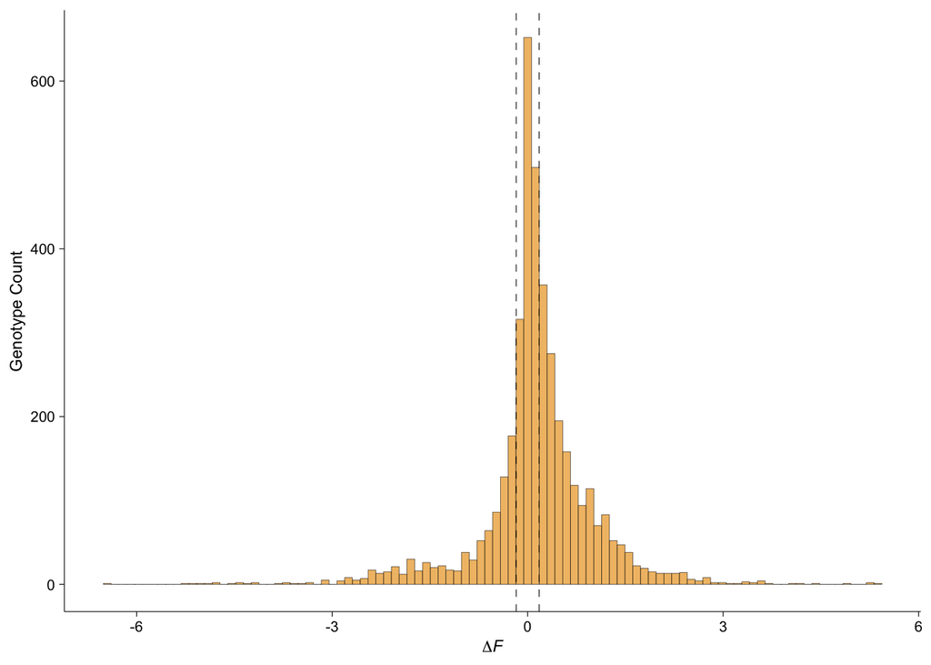

#### Spread in SMEs - 2SD

We have 214 positions.

##### Histogram of 2SD - SMEs

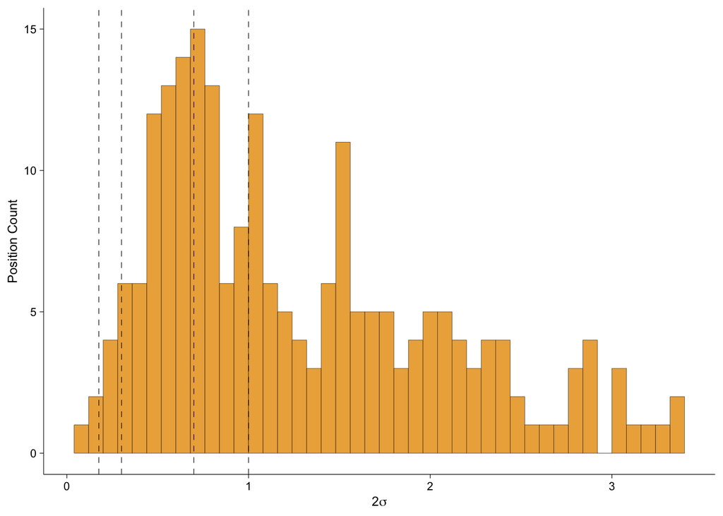

##### Table of 2SD - SMEs

First order positions which have a heterogeneity index > log10 1.5-fold, 2-fold, 5-fold, and 10-fold for adaptive trajectories

| mutations | idiosync_sig_1.5 | idiosync_sig_2 | idiosync_sig_5 | idiosync_sig_10 | idiosync_total | idiosync_1.5 | idiosync_2 | idiosync_5 | idiosync_10 |
| --- | --- | --- | --- | --- | --- | --- | --- | --- | --- |
| Order 1 | 211 | 205 | 150 | 114 | 214 | 98.59813 | 95.79439 | 70.09346 | 53.27103 |

#### Spread in SMEs - sign

First we upload all SME and EE data for sign changing

Then, we assigning positive, neutral, negative, negative-neutral, positive-neutral, and negative-positive ‘types’ based on log10 1.5-fold threshold to every Order

If one chooses to probe the variable `higher_all_sign_check`, it will show position/combination numbers in each category, followed by the total sum of all probed positions/combinations at that order, and finally percentages of each category

##### Piechart of sign - SMEs

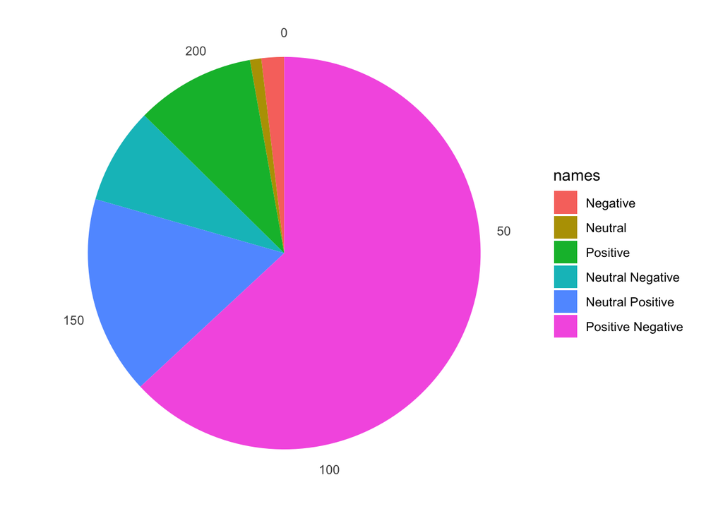

Note, the aesthetics of the pie charts were edited elsewhere for publication.

##### Table of sign - SMEs and EEs

Raw Values

| mutations | Negative | Neutral | Neutral Negative | Neutral Positive | Positive | Positive Negative | Total |
| --- | --- | --- | --- | --- | --- | --- | --- |
| Order 1 | 4 | 2 | 17 | 35 | 21 | 135 | 214 |
| Order 2 | 5 | 5 | 37 | 63 | 13 | 296 | 419 |
| Order 3 | 15 | 10 | 63 | 59 | 51 | 240 | 438 |
| Order 4 | 11 | 5 | 50 | 42 | 11 | 126 | 245 |
| Order 5 | 5 | 4 | 12 | 18 | 6 | 39 | 84 |
| Order 6 | 1 | 2 | 2 | 2 | 1 | 6 | 14 |

Percentages

| mutations | Negative | Neutral | Neutral Negative | Neutral Positive | Positive | Positive Negative | Total |
| --- | --- | --- | --- | --- | --- | --- | --- |
| Order 1 | 1.869159 | 0.9345794 | 7.943925 | 16.35514 | 9.813084 | 63.08411 | 214 |
| Order 2 | 1.193317 | 1.1933174 | 8.830549 | 15.03580 | 3.102625 | 70.64439 | 419 |
| Order 3 | 3.424657 | 2.2831050 | 14.383562 | 13.47032 | 11.643836 | 54.79452 | 438 |
| Order 4 | 4.489796 | 2.0408163 | 20.408163 | 17.14286 | 4.489796 | 51.42857 | 245 |
| Order 5 | 5.952381 | 4.7619048 | 14.285714 | 21.42857 | 7.142857 | 46.42857 | 84 |
| Order 6 | 7.142857 | 14.2857143 | 14.285714 | 14.28571 | 7.142857 | 42.85714 | 14 |

#### Spread in SMEs - wt/mean dev

Purpose of this analysis was to determine the difference in SMEs between the WT-background contribution of a given position/combination and the mean contribution of a given position or combination

First, we load the spread of every positional contribution vs mean differences for SMEs

##### Histogram of wt/mean dev - SMEs

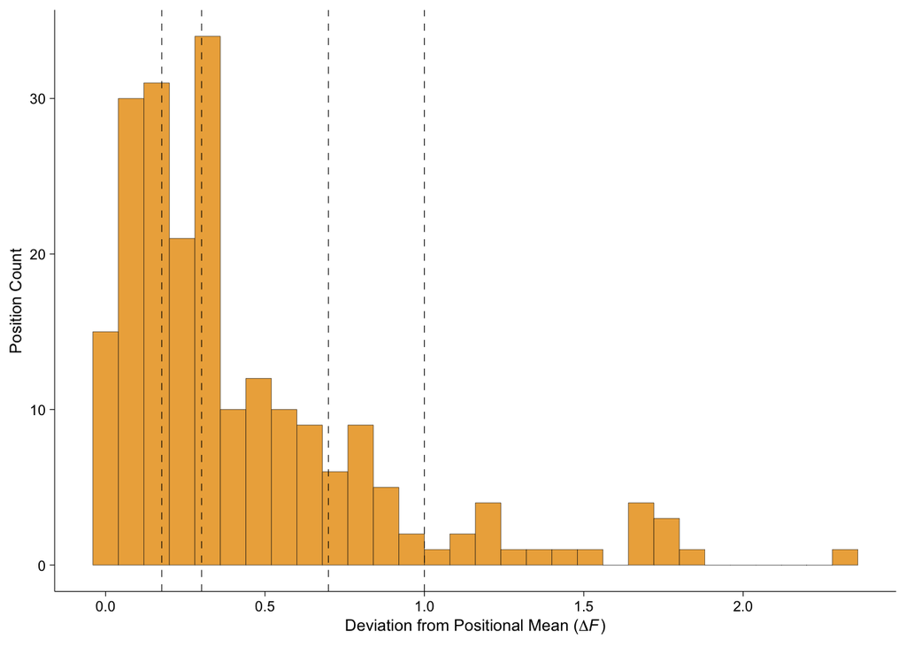

In the manuscript, we also briefly mentioned how many WT SMEs have sign deviation (not just magnitude) from the mean at the 1st order? This is in fact 3.27% (7/214).

##### Table of wt/mean dev - SMEs

Also, in the supplementary of our paper, we show this table to show percentages of WT-bg points that deviate from the positional/combinatorial mean by multiple significance threshold (log10 1.5-, 2-, 5-, and 10-fold)

| Order | percent_1.5 | outlier_1.5 | percent_2 | outlier_2 | percent_5 | outlier_5 | percent_10 | outlier_10 | total |
| --- | --- | --- | --- | --- | --- | --- | --- | --- | --- |
| 1 | 67.8 | 145 | 51.4 | 110 | 19.2 | 41 | 9.3 | 20 | 214 |
| 2 | 64.4 | 270 | 51.3 | 215 | 21.5 | 90 | 9.8 | 41 | 419 |
| 3 | 55.9 | 245 | 35.2 | 154 | 19.2 | 84 | 13.9 | 61 | 438 |
| 4 | 62.4 | 153 | 33.9 | 83 | 9.0 | 22 | 6.9 | 17 | 245 |

As well as the devation of every single SME and EE from the mean, instead of just the wt background. This corresponds to extended data table 4.

##### Table of all SME and EE to mean dev (extended data table 4)

| Order | percent_1.5 | outlier_1.5 | percent_2 | outlier_2 | percent_5 | outlier_5 | percent_10 | outlier_10 | total |
| --- | --- | --- | --- | --- | --- | --- | --- | --- | --- |
| 1 | 0.5888287 | 2393 | 0.4040354 | 1642 | 0.1483760 | 603 | 0.0809547 | 329 | 4064 |
| 2 | 0.5286815 | 2470 | 0.3488870 | 1630 | 0.1316353 | 615 | 0.0747003 | 349 | 4672 |
| 3 | 0.4963038 | 1477 | 0.3114919 | 927 | 0.1202957 | 358 | 0.0796371 | 237 | 2976 |
| 4 | 0.5598214 | 627 | 0.3455357 | 387 | 0.0991071 | 111 | 0.0589286 | 66 | 1120 |

### Idiosyncrasy in epistatic effects

#### Spread in EEs - 2SD

Histogram to show heterogenity at Orders 2, 3, and 4 with the log10 1.5-fold significance threshold

##### Histogram of 2SD - pairwise

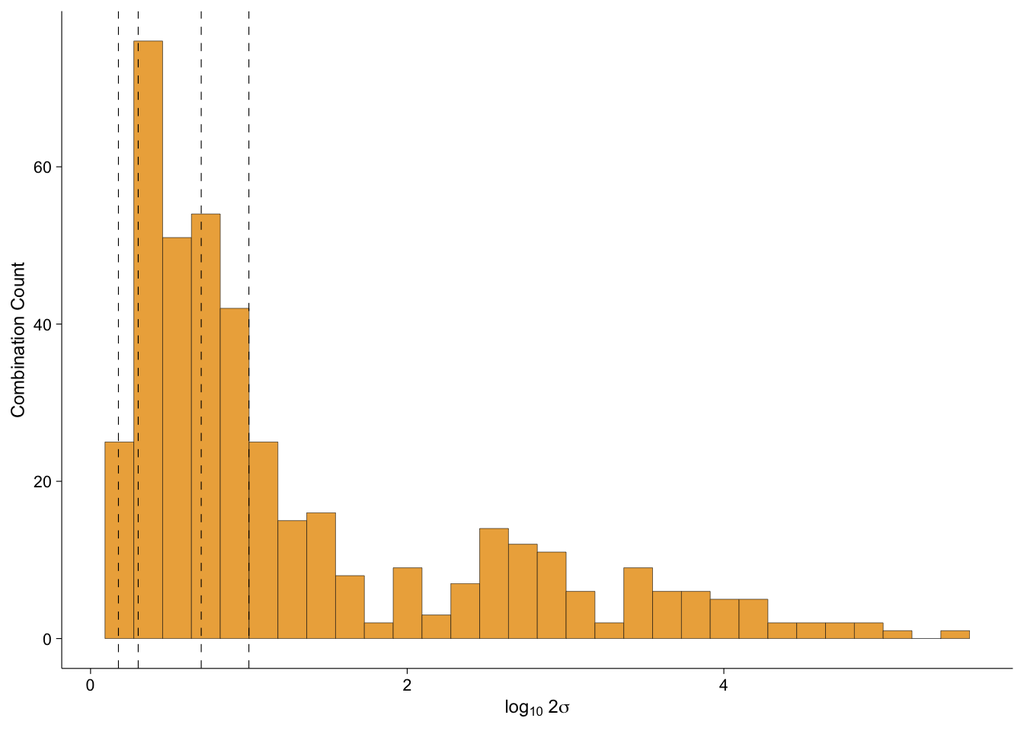

##### Histogram of 2SD - three-way

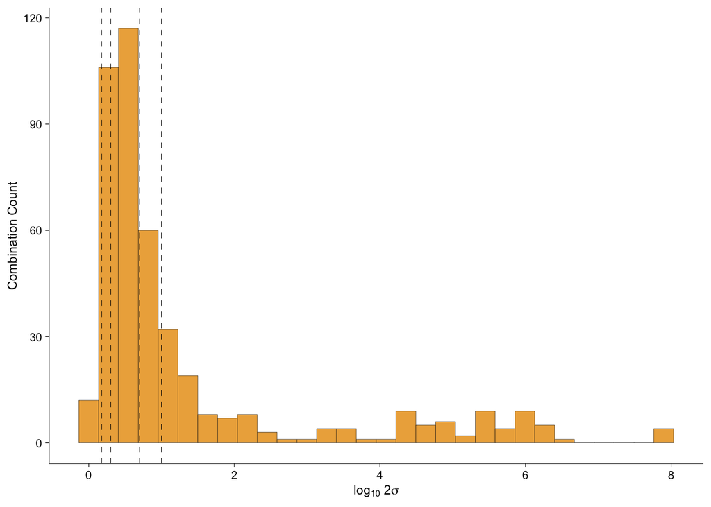

##### Histogram of 2SD - four-way

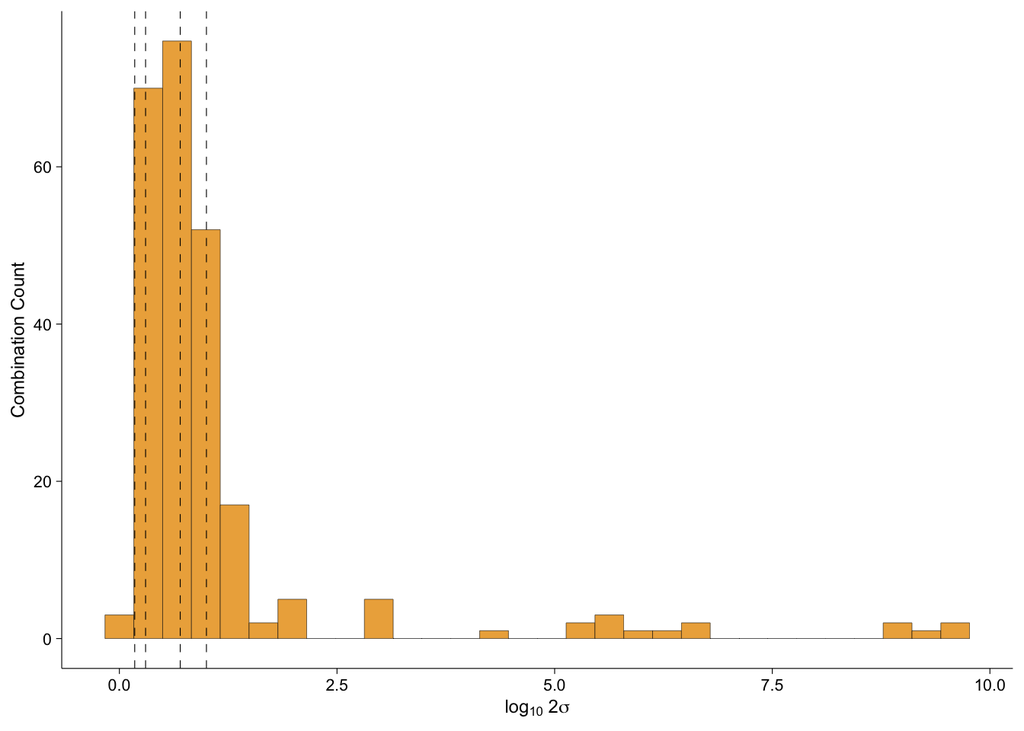

##### Table of 2SD in all EEs - Extended data table 1

What percentage of positions remain significantly heterogeneous (1.5-, 2-, 5-, and 10-fold) at all orders?

| mutations | idiosync_sig_1.5 | idiosync_sig_2 | idiosync_sig_5 | idiosync_sig_10 | idiosync_total | idiosync_1.5 | idiosync_2 | idiosync_5 | idiosync_10 |
| --- | --- | --- | --- | --- | --- | --- | --- | --- | --- |
| Order 1 | 211 | 205 | 150 | 114 | 214 | 98.59813 | 95.79439 | 70.09346 | 53.27103 |
| Order 2 | 413 | 387 | 253 | 172 | 419 | 98.56802 | 92.36277 | 60.38186 | 41.05012 |
| Order 3 | 420 | 374 | 199 | 136 | 438 | 95.89041 | 85.38813 | 45.43379 | 31.05023 |
| Order 4 | 240 | 204 | 122 | 61 | 245 | 97.95918 | 83.26531 | 49.79592 | 24.89796 |

#### Spread in EEs - sign

##### Piechart of sign - EE pairiwise

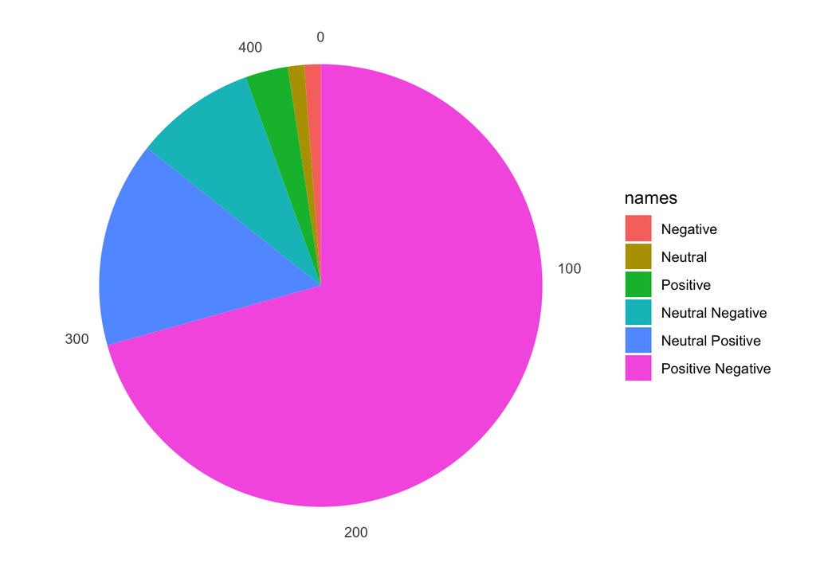

##### Piechart of sign - EE three-way

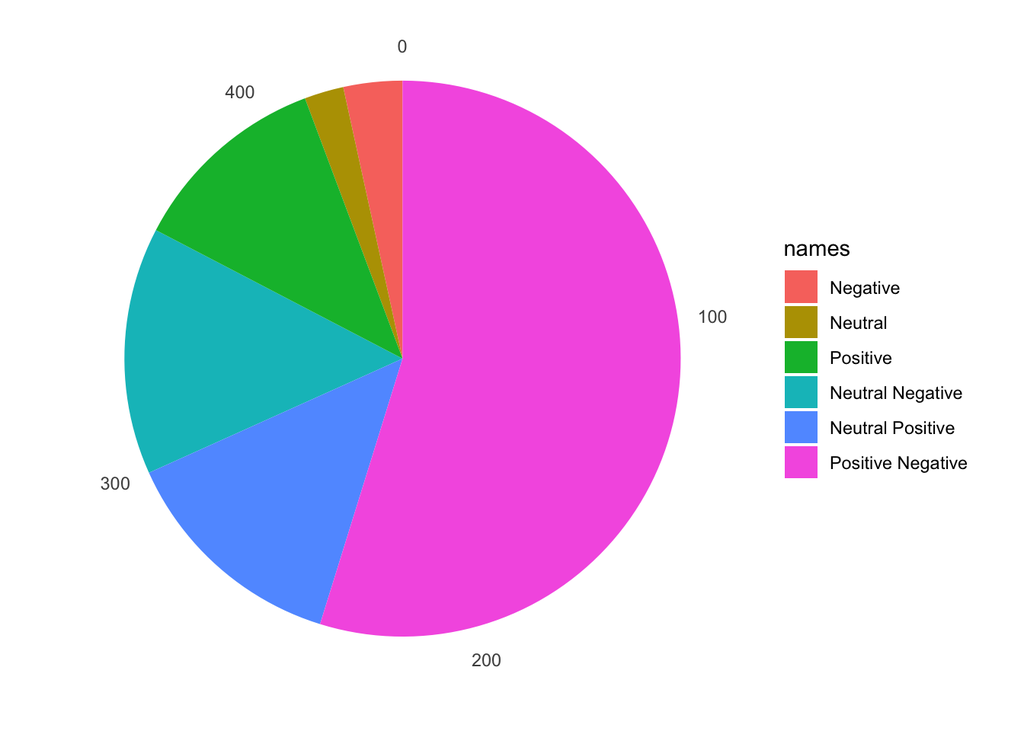

##### Piechart of sign - EE four-way

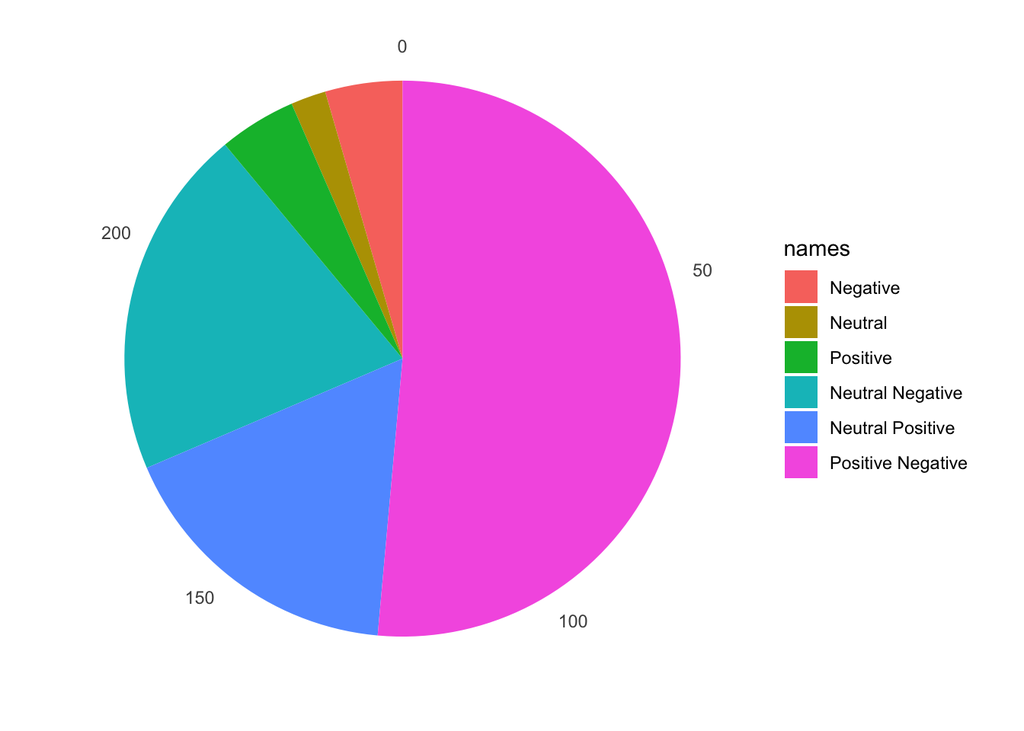

#### Spread in EEs - wt/mean dev

##### Histogram of wt/mean dev - pairwise EEs

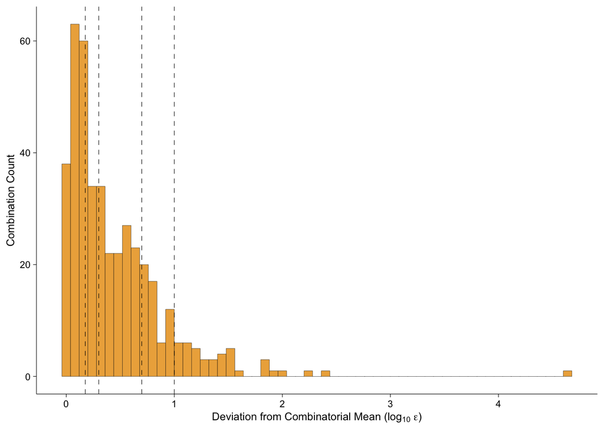

##### Histogram of wt/mean dev - three-way EEs

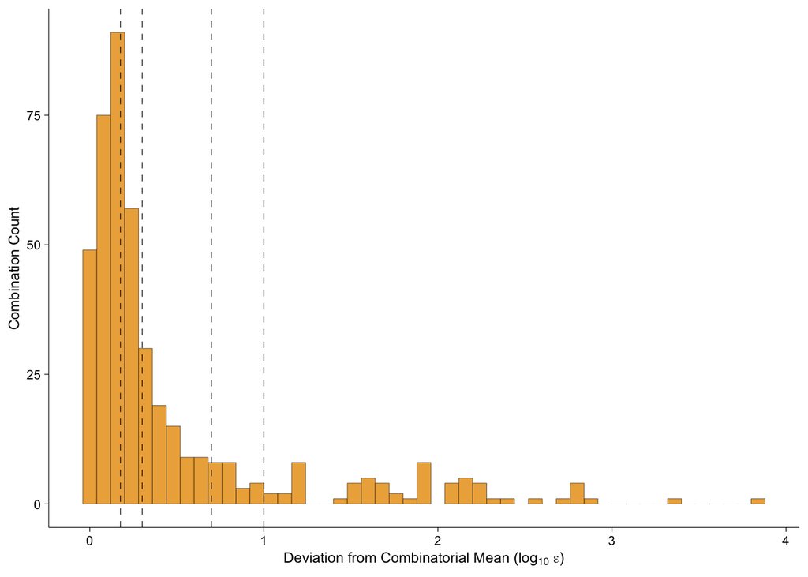

##### Histogram of wt/mean dev - four-way EEs

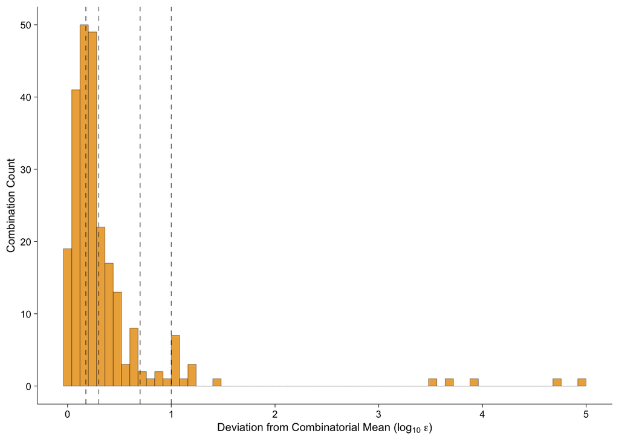

Like the SMEs, we checked whether there is a sign deviation between the wt EE and mean EE at each order of interaction. For pairwise we saw 53/419 (12.65%). For three-way we saw 34/438 (7.76%). For four-way we saw 12/245 (4.9%).

### Network rewiring

First we load the required data for network rewiring exploration, as well as establish filters for adaptive trajectories and ‘mechanistic’ trajectories.

Then we look at how many network rewiring events there are.

| epistasis at lower-order? | epistasis at higher-order? | n | percentage |
| --- | --- | --- | --- |
| FALSE | FALSE | 186 | 18.11100 |
| FALSE | TRUE | 228 | 22.20058 |
| TRUE | FALSE | 159 | 15.48199 |
| TRUE | TRUE | 454 | 44.20643 |

Of the rewired, how many are constructive and how many are destructive?

| event_type | n | percentage |
| --- | --- | --- |
| constructive | 82 | 18.06167 |
| disruptive | 372 | 81.93833 |

### Molecular basis

This analysis was bespoke, but surveying all network rewiring events manually and selecting genotypes along adaptive trajectories.

## Supplementary

### Error-rate assessment

Take all the input files, attach their unique_id, find the ones with replicates, then look at the median of 2*SD (~95% spread around measurement mean) for all measurements to decided on an approriate significance threshold

```r
file_vector = str_remove(list.files(path = "Input", pattern="*.csv", recursive = T), ".csv")

error_set = lapply(paste0("Input/", list.files(path = "Input", pattern="*.csv", recursive = T)), read_csv, skip = 5, col_names = F, col_select = 1:2, show_col_types=F)

for(i in 1:length(error_set)){
  error_set[[i]][,3] = file_vector[i]
}

error_set = do.call("rbind", error_set)

colnames(error_set) = c("Genotype", "Phenotype", "unique_id")

error_rates = error_set[which(duplicated(error_set %>%
  unite(unique_geno, c(1,3), sep = "_", remove = F) %>%
  pull(unique_geno))),] %>%
  group_by(Genotype) %>%
  summarise(pheno_mean = mean(Phenotype),
            pheno_sd = sd(Phenotype))

## % of SDs for measurements that are less than 1.5-fold threshold

sum(error_rates$pheno_sd*2 <= log10(1.5)) / length(error_rates$pheno_sd)
```

```
## [1] 0.5170068
```

```r
median(error_rates$pheno_sd*2)
```

```
## [1] 0.1705538
```

```r
summary(error_rates$pheno_sd*2)
```

```
##    Min. 1st Qu.  Median    Mean 3rd Qu.    Max.
## 0.00000 0.08511 0.17055 0.71405 0.74638 3.73452
```

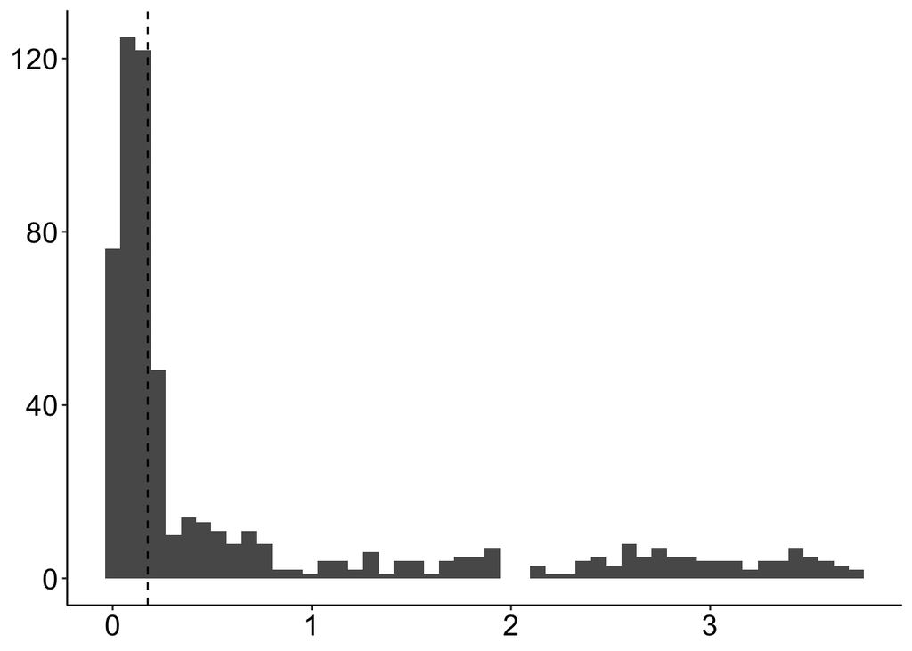

```r
error_rates %>%
  ggplot(aes(x = pheno_sd*2)) +
  geom_histogram(bins = 50) +
  geom_vline(xintercept = log10(1.5), lty = 2) +
  theme_classic() +
  theme(text = element_text(size=18), axis.text = element_text(size = 16, color = "black"),
        axis.title.y = element_blank(),
        axis.title.x = element_blank(),
        legend.position = "none")
```